# R Notebook

Melvin and Shayar

Understanding Life Expectancy of the world

**Problem Statement:** To analyze and predict Life Expectancy based on various socioeconomic and health-related indicators

**Inspiration**:

The data-set aims to answer the following key questions:

- Does various predicting factors which has been chosen initially really affect the Life expectancy? What are the predicting variables actually affecting the life expectancy?
- Should a country having a lower life expectancy value(<65) increase its healthcare expenditure in order to improve its average lifespan?
- How does Infant and Adult mortality rates affect life expectancy?
- Does Life Expectancy has positive or negative correlation with eating habits, lifestyle, exercise, smoking, drinking alcohol etc.
- What is the impact of schooling on the lifespan of humans?
- Does Life Expectancy have positive or negative relationship with drinking alcohol?
- Do densely populated countries tend to have lower life expectancy?
- What is the impact of Immunization coverage on life Expectancy?

Data set link:- https://www.kaggle.com/datasets/kumarajarshi/life-expectancy-who/data

# **Step 1: Setting up Important Libraries**

```r
#install.packages("caret")
install.packages("Metrics")
library(ggplot2)
library(dplyr)
library(caret)
library(MASS)
library(car)
library(Metrics)
```

# **Step 2: Data Acquisition**

```r
WHO_life_expectancy_data <- read.csv('Life Expectancy Data.csv')
head(WHO_life_expectancy_data)
```

|  | Country | Year | Status | Life.expectancy | Adult.Mortality | infant.deaths | Alcohol | percentage.expenditure | Hepatitis.B | Measles | BMI | under.five.deaths | Polio | Total.expenditure | Diphtheria | HIV.AIDS | GDP | Population | thinness..1.19.years | thinness.5.9.years | Income.composition.of.resources | Schooling |
| --- | --- | --- | --- | --- | --- | --- | --- | --- | --- | --- | --- | --- | --- | --- | --- | --- | --- | --- | --- | --- | --- | --- |
| 1 | Afghanistan | 2015 | Developing | 65.0 | 263 | 62 | 0.01 | 71.279624 | 65 | 1154 | 19.1 | 83 | 6 | 8.16 | 65 | 0.1 | 584.25921 | 33736494 | 17.2 | 17.3 | 0.479 | 10.1 |
| 2 | Afghanistan | 2014 | Developing | 59.9 | 271 | 64 | 0.01 | 73.523582 | 62 | 492 | 18.6 | 86 | 58 | 8.18 | 62 | 0.1 | 612.69651 | 327582 | 17.5 | 17.5 | 0.476 | 10.0 |
| 3 | Afghanistan | 2013 | Developing | 59.9 | 268 | 66 | 0.01 | 73.219243 | 64 | 430 | 18.1 | 89 | 62 | 8.13 | 64 | 0.1 | 631.74498 | 31731688 | 17.7 | 17.7 | 0.470 | 9.9 |
| 4 | Afghanistan | 2012 | Developing | 59.5 | 272 | 69 | 0.01 | 78.184215 | 67 | 2787 | 17.6 | 93 | 67 | 8.52 | 67 | 0.1 | 669.95900 | 3696958 | 17.9 | 18.0 | 0.463 | 9.8 |
| 5 | Afghanistan | 2011 | Developing | 59.2 | 275 | 71 | 0.01 | 7.097109 | 68 | 3013 | 17.2 | 97 | 68 | 7.87 | 68 | 0.1 | 63.53723 | 2978599 | 18.2 | 18.2 | 0.454 | 9.5 |
| 6 | Afghanistan | 2010 | Developing | 58.8 | 279 | 74 | 0.01 | 79.679367 | 66 | 1989 | 16.7 | 102 | 66 | 9.20 | 66 | 0.1 | 553.32894 | 2883167 | 18.4 | 18.4 | 0.448 | 9.2 |

We have fetched the dataset using the csv file download from the kaggle website. Now, we have also tried to see how the data looks and single it we can.

# **Step 3: Exploratory Data Analysis (EDA) Before Handling Missing Values**

```r
colSums(is.na(WHO_life_expectancy_data))
```

```
                        Country                            Year
                              0                               0
                         Status                 Life.expectancy
                              0                              10
                Adult.Mortality                   infant.deaths
                             10                               0
                        Alcohol          percentage.expenditure
                            194                               0
                    Hepatitis.B                         Measles
                            553                               0
                            BMI               under.five.deaths
                             34                               0
                          Polio               Total.expenditure
                             19                             226
                     Diphtheria                        HIV.AIDS
                             19                               0
                            GDP                      Population
                            448                             652
           thinness..1.19.years              thinness.5.9.years
                             34                              34
Income.composition.of.resources                       Schooling
                            167                             163
```

Population, Hepatitis B, GDP are among the top 3 features with most missing values out of 2938 entries.

```r
summary(WHO_life_expectancy_data)
```

```
   Country               Year         Status          Life.expectancy Adult.Mortality
 Length:2938        Min.   :2000   Length:2938        Min.   :36.30   Min.   :  1.0
 Class :character   1st Qu.:2004   Class :character   1st Qu.:63.10   1st Qu.: 74.0
 Mode  :character   Median :2008   Mode  :character   Median :72.10   Median :144.0
                    Mean   :2008                      Mean   :69.22   Mean   :164.8
                    3rd Qu.:2012                      3rd Qu.:75.70   3rd Qu.:228.0
                    Max.   :2015                      Max.   :89.00   Max.   :723.0
                                                      NA's   :10      NA's   :10
 infant.deaths       Alcohol        percentage.expenditure  Hepatitis.B
 Min.   :   0.0   Min.   : 0.0100   Min.   :    0.000      Min.   : 1.00
 1st Qu.:   0.0   1st Qu.: 0.8775   1st Qu.:    4.685      1st Qu.:77.00
 Median :   3.0   Median : 3.7550   Median :   64.913      Median :92.00
 Mean   :  30.3   Mean   : 4.6029   Mean   :  738.251      Mean   :80.94
 3rd Qu.:  22.0   3rd Qu.: 7.7025   3rd Qu.:  441.534      3rd Qu.:97.00
 Max.   :1800.0   Max.   :17.8700   Max.   :19479.912      Max.   :99.00
                  NA's   :194                              NA's   :553
    Measles              BMI        under.five.deaths     Polio
 Min.   :     0.0   Min.   : 1.00   Min.   :   0.00   Min.   : 3.00
 1st Qu.:     0.0   1st Qu.:19.30   1st Qu.:   0.00   1st Qu.:78.00
 Median :    17.0   Median :43.50   Median :   4.00   Median :93.00
 Mean   :  2419.6   Mean   :38.32   Mean   :  42.04   Mean   :82.55
 3rd Qu.:   360.2   3rd Qu.:56.20   3rd Qu.:  28.00   3rd Qu.:97.00
 Max.   :212183.0   Max.   :87.30   Max.   :2500.00   Max.   :99.00
                    NA's   :34                        NA's   :19
 Total.expenditure   Diphtheria       HIV.AIDS           GDP
 Min.   : 0.370    Min.   : 2.00   Min.   : 0.100   Min.   :     1.68
 1st Qu.: 4.260    1st Qu.:78.00   1st Qu.: 0.100   1st Qu.:   463.94
 Median : 5.755    Median :93.00   Median : 0.100   Median :  1766.95
 Mean   : 5.938    Mean   :82.32   Mean   : 1.742   Mean   :  7483.16
 3rd Qu.: 7.492    3rd Qu.:97.00   3rd Qu.: 0.800   3rd Qu.:  5910.81
 Max.   :17.600    Max.   :99.00   Max.   :50.600   Max.   :119172.74
 NA's   :226       NA's   :19                       NA's   :448
   Population        thinness..1.19.years thinness.5.9.years
 Min.   :3.400e+01   Min.   : 0.10        Min.   : 0.10
 1st Qu.:1.958e+05   1st Qu.: 1.60        1st Qu.: 1.50
 Median :1.387e+06   Median : 3.30        Median : 3.30
 Mean   :1.275e+07   Mean   : 4.84        Mean   : 4.87
 3rd Qu.:7.420e+06   3rd Qu.: 7.20        3rd Qu.: 7.20
 Max.   :1.294e+09   Max.   :27.70        Max.   :28.60
 NA's   :652         NA's   :34           NA's   :34
 Income.composition.of.resources   Schooling
 Min.   :0.0000                  Min.   : 0.00
 1st Qu.:0.4930                  1st Qu.:10.10
 Median :0.6770                  Median :12.30
 Mean   :0.6276                  Mean   :11.99
 3rd Qu.:0.7790                  3rd Qu.:14.30
 Max.   :0.9480                  Max.   :20.70
 NA's   :167                     NA's   :163
```

Now, we be trying to visualize the missing values using histograms and box plots for numerical values and Barplots for categorical values.

Starting with having numerical columns and categorical columns in two different data frames.

```r
nums_col <- names(WHO_life_expectancy_data)[sapply(WHO_life_expectancy_data, is.numeric)]

cat_col <- names(WHO_life_expectancy_data)[sapply(WHO_life_expectancy_data, function(x) is.factor(x) || is.character(x))]
```

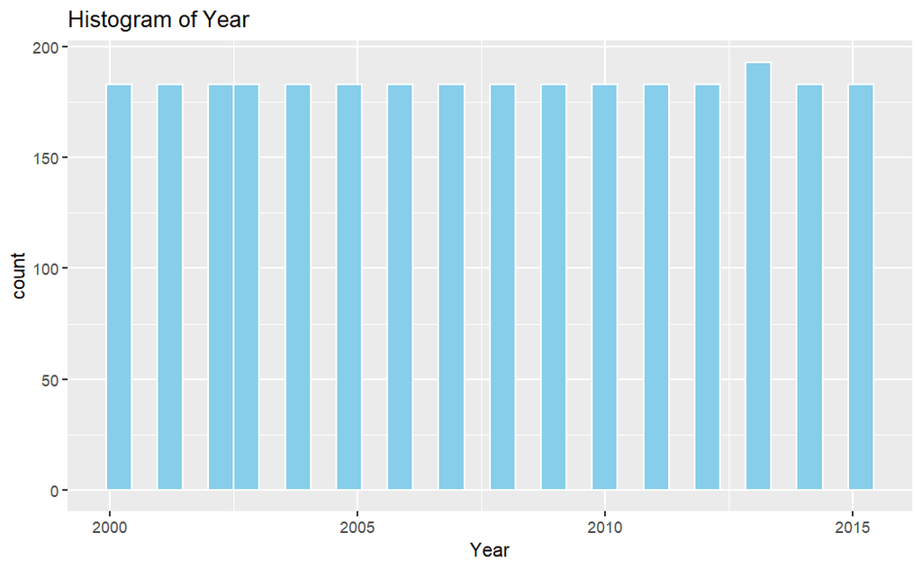

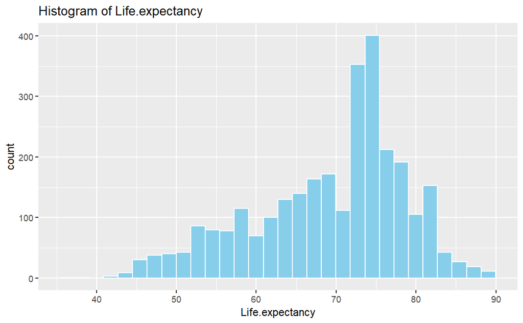

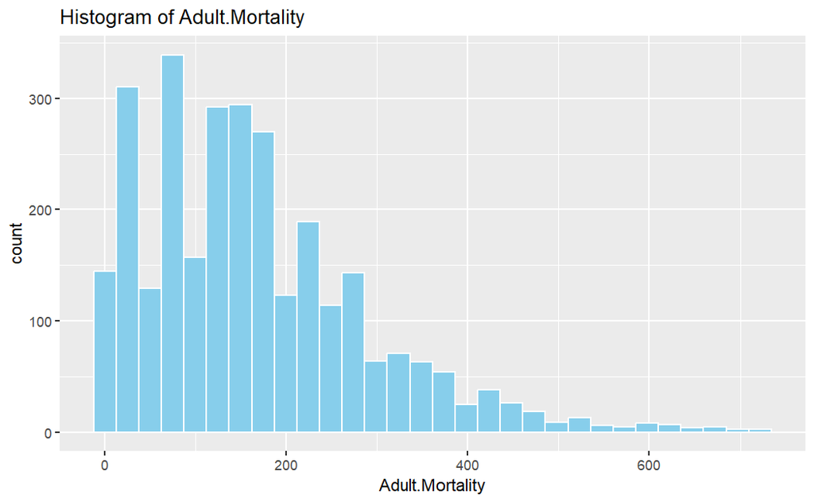

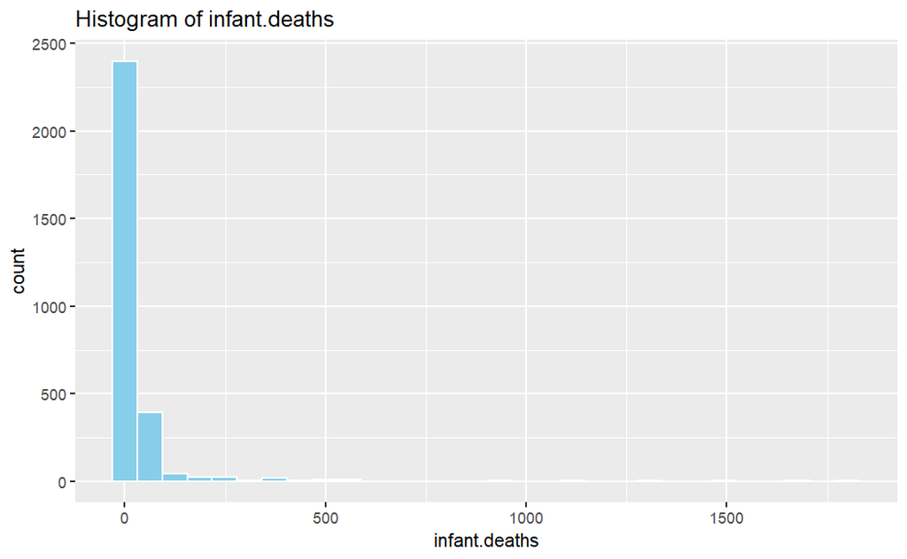

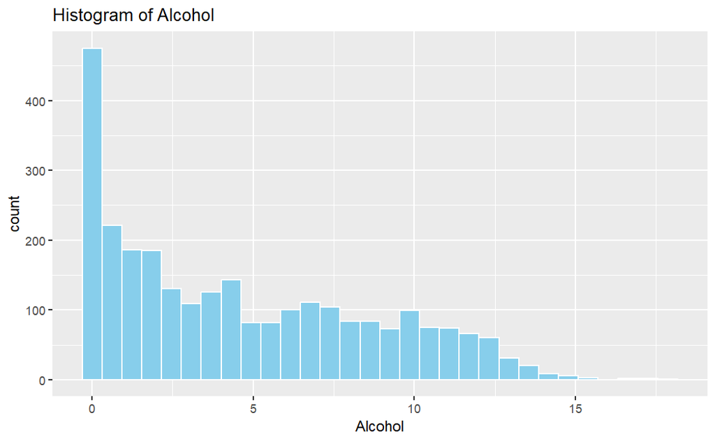

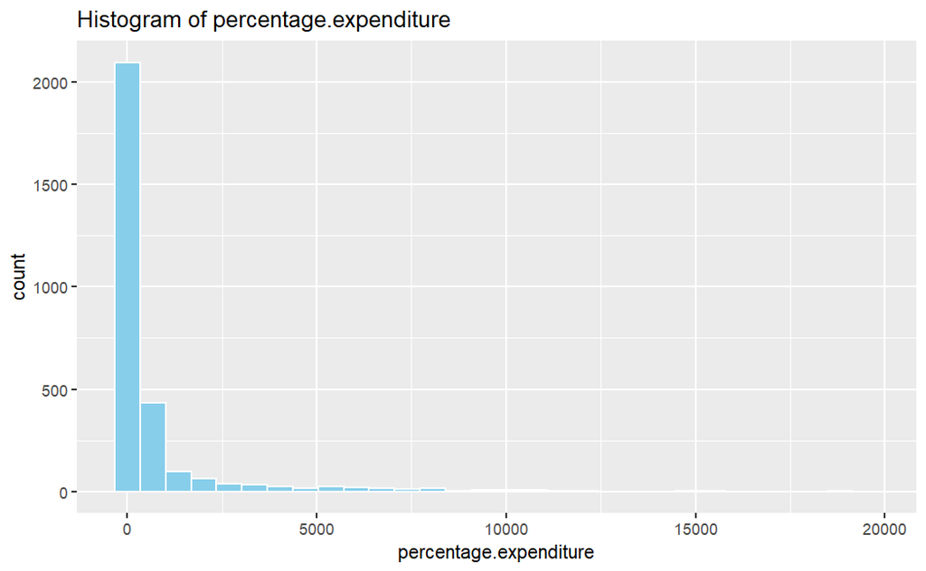

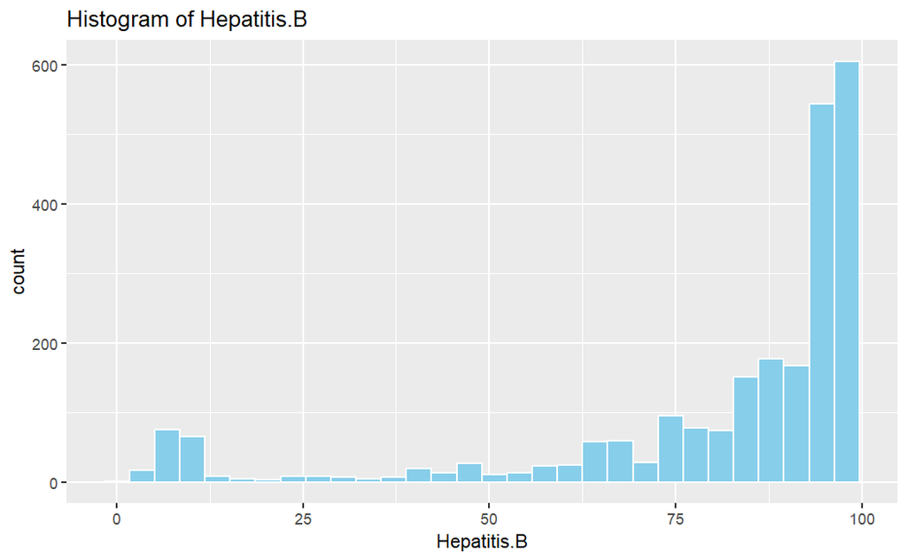

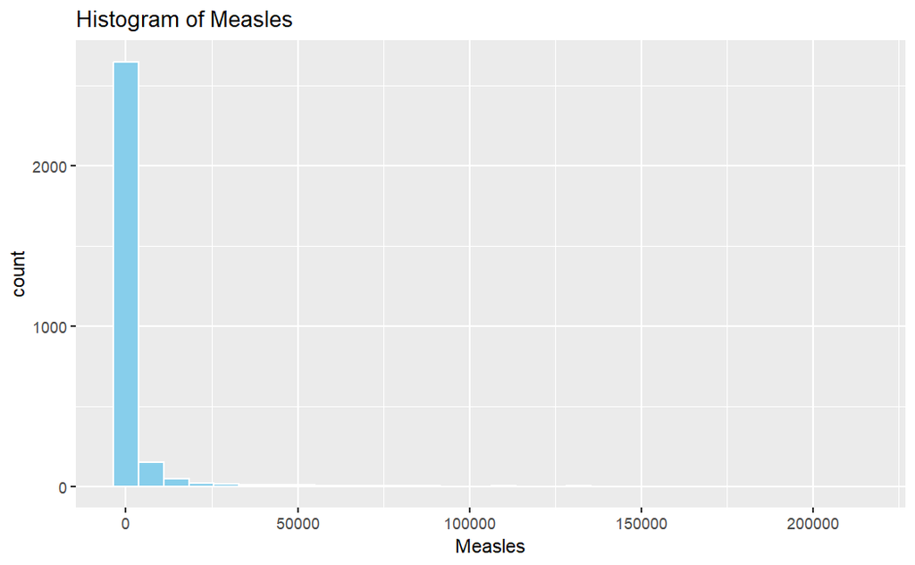

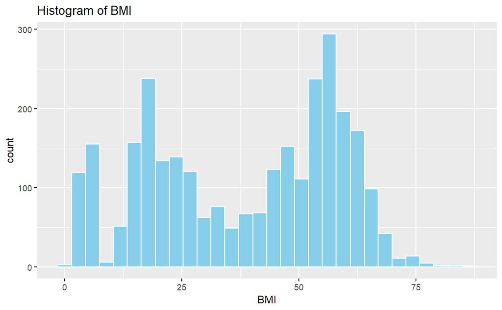

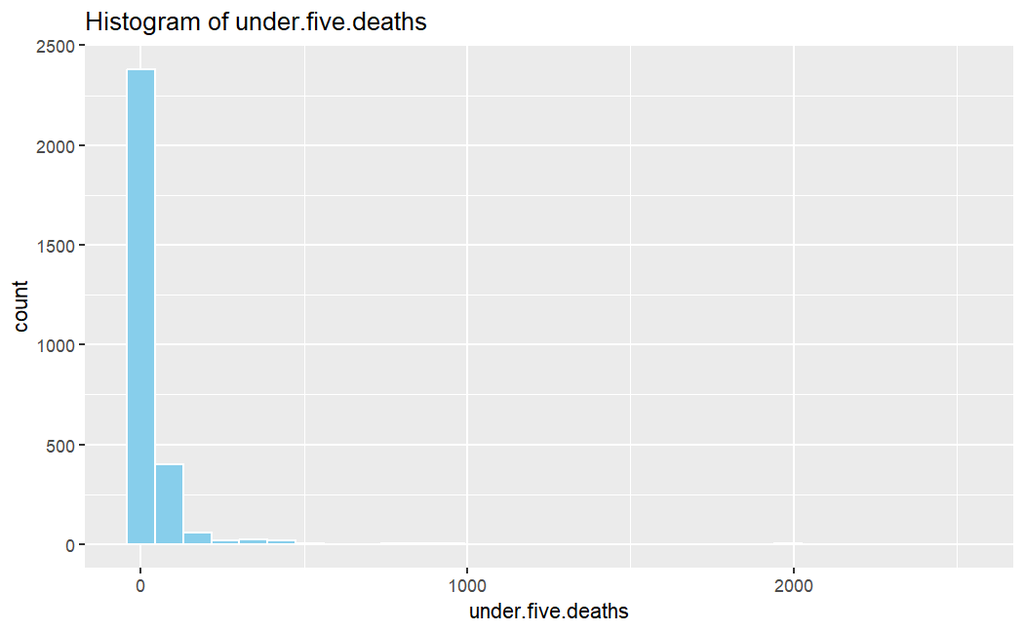

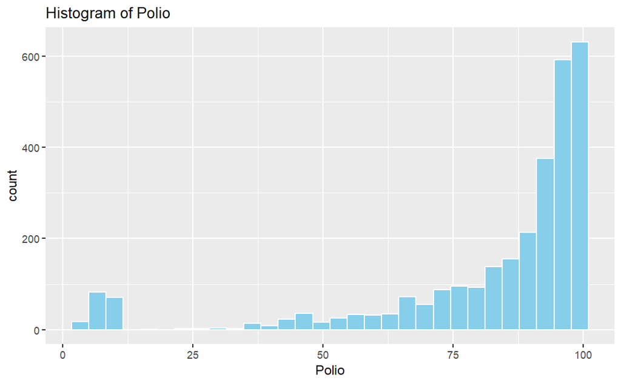

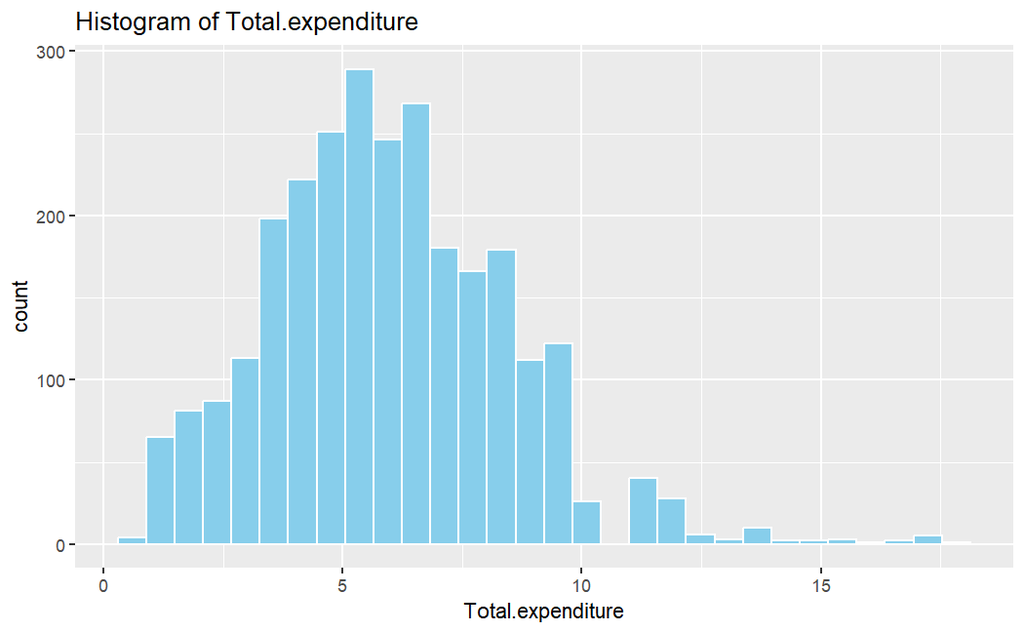

[8 more figures not shown]

```r
# Histograms for numerical columns
for (col in nums_col) {
  print(
    ggplot(WHO_life_expectancy_data, aes_string(x = col)) +
      geom_histogram(bins = 30, fill = "skyblue", color = "white") +
      ggtitle(paste("Histogram of", col))
  )
}
```

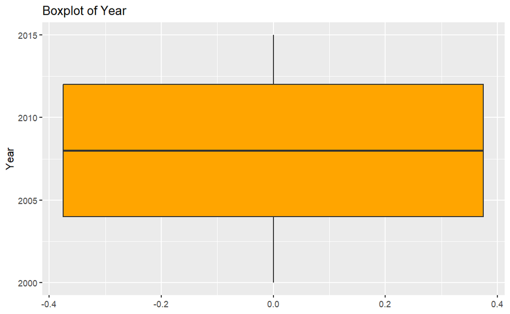

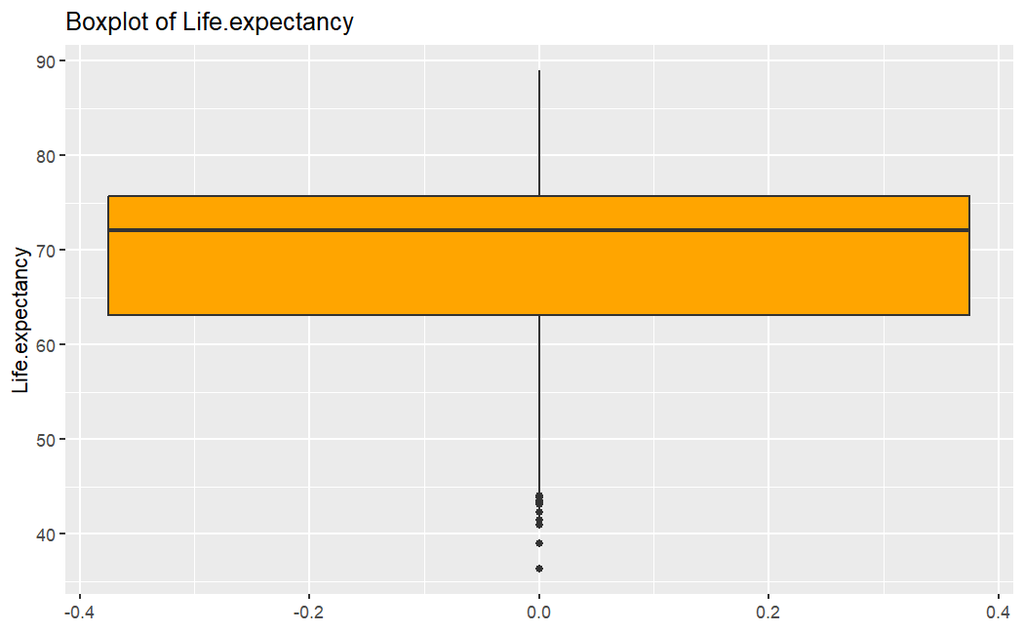

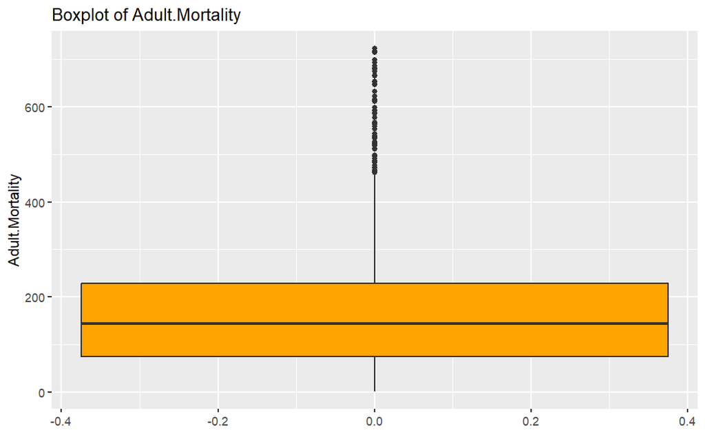

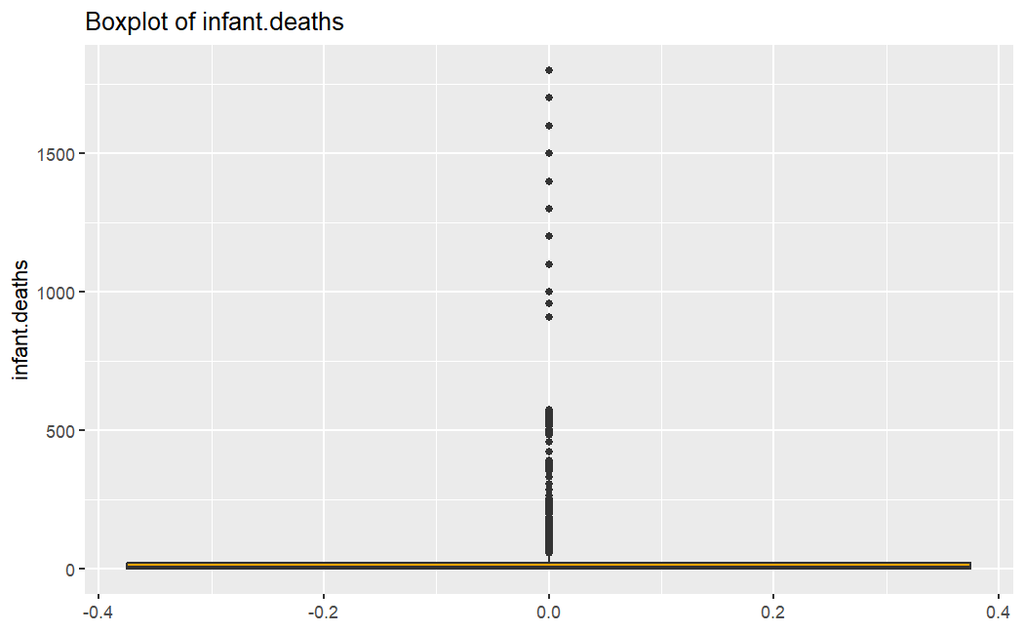

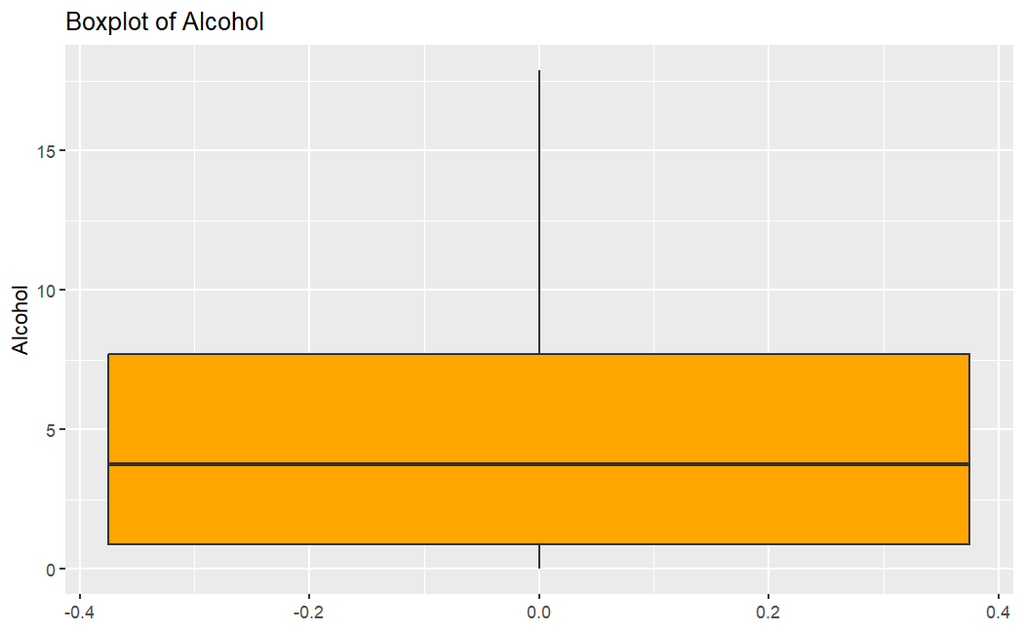

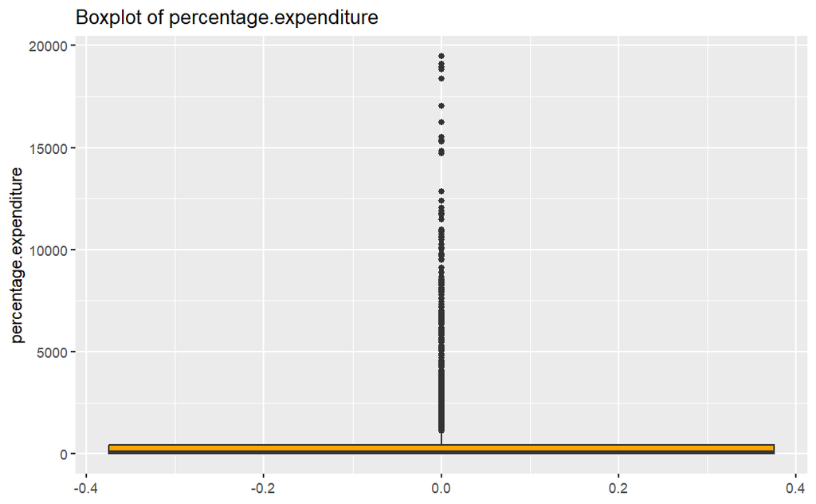

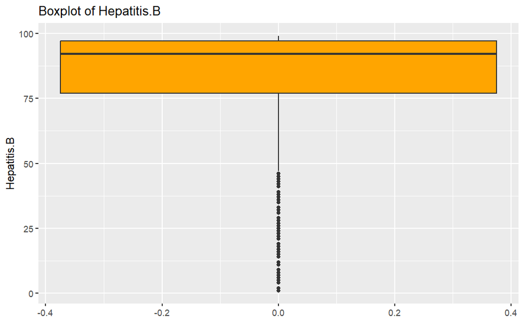

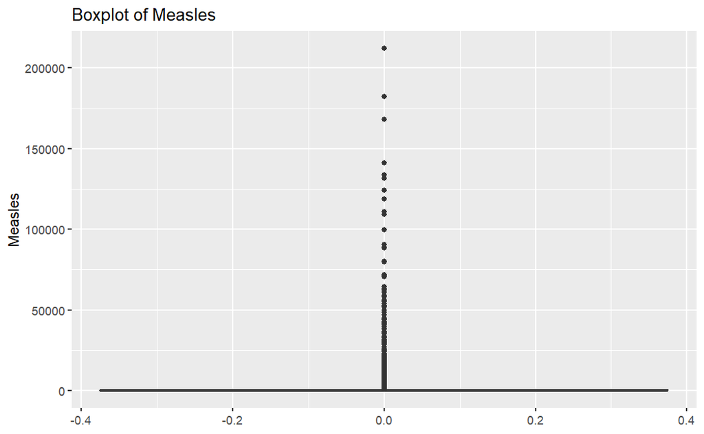

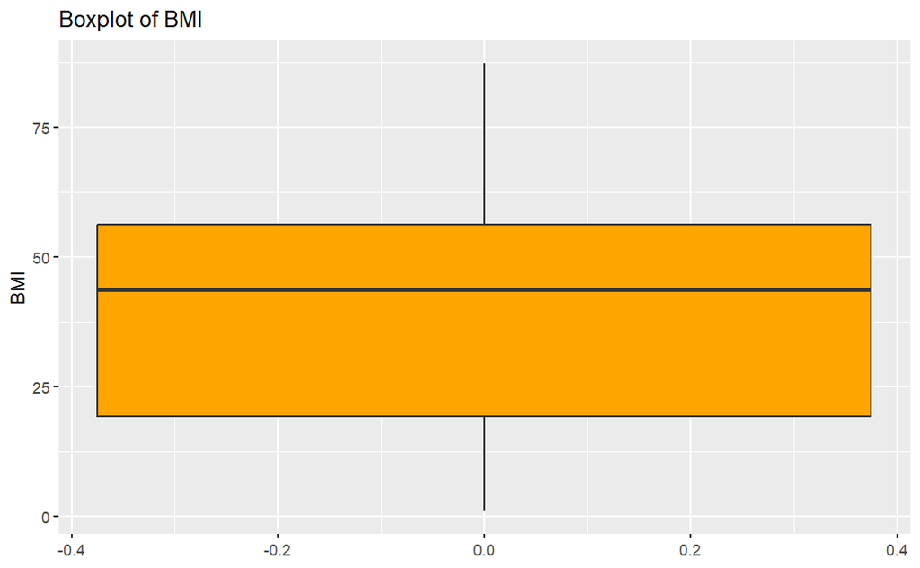

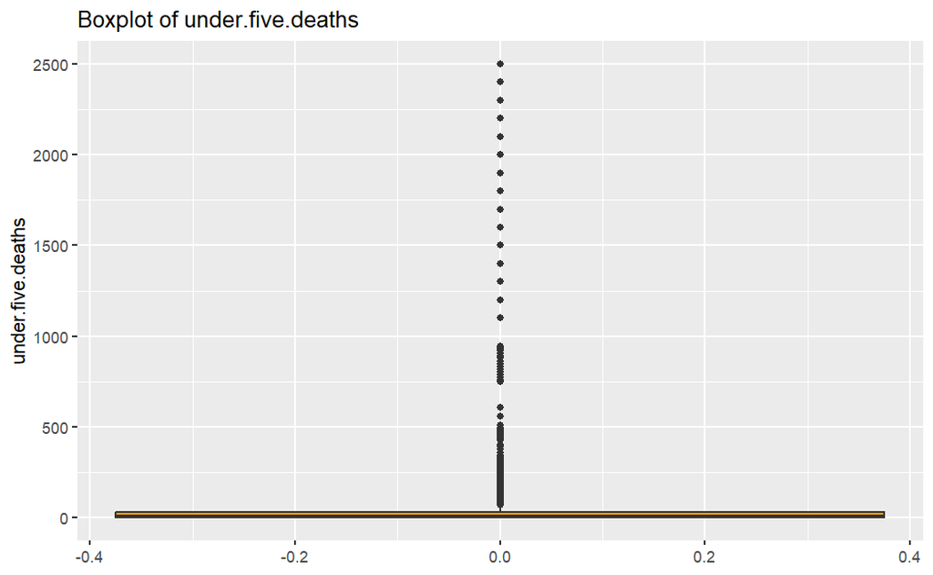

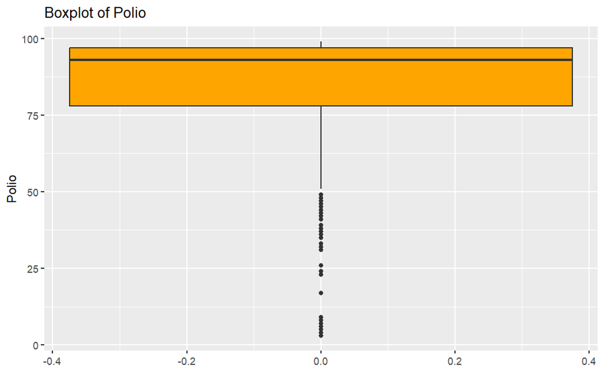

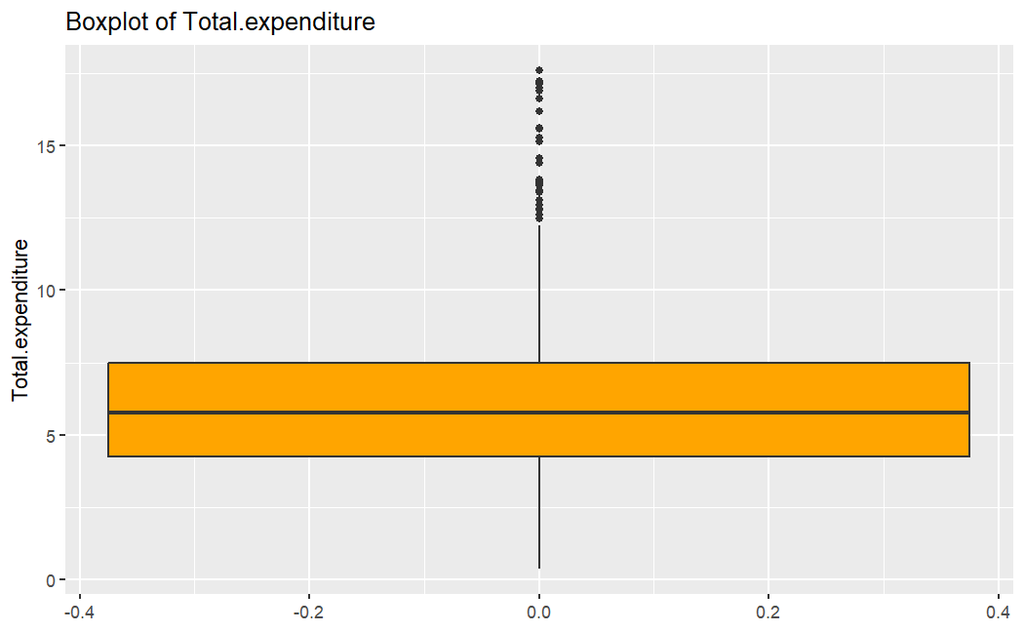

[8 more figures not shown]

```r
# Boxplots for numerical columns
for (col in nums_col) {
  print(
    ggplot(WHO_life_expectancy_data, aes_string(y = col)) +
      geom_boxplot(fill = "orange") +
      ggtitle(paste("Boxplot of", col))
  )
}
```

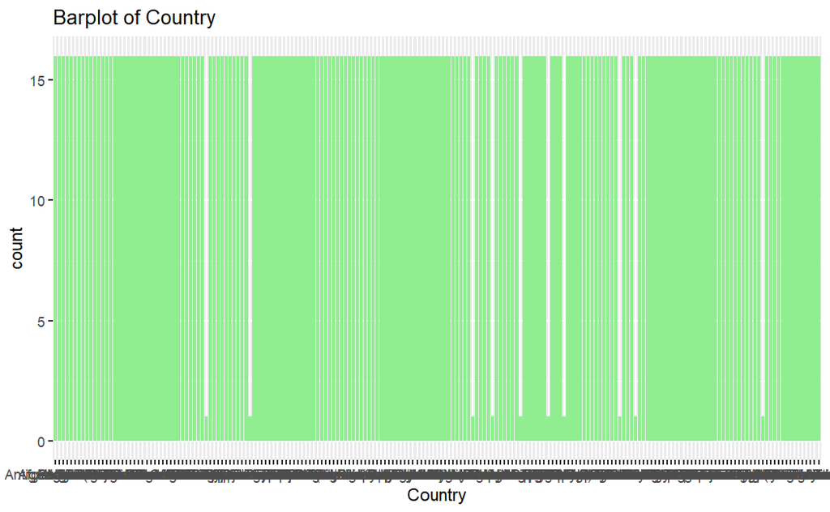

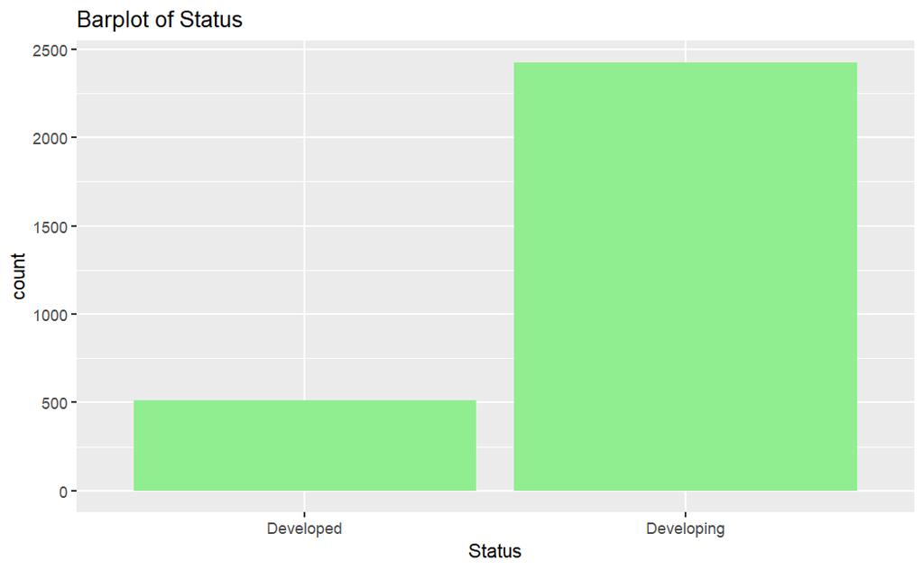

```r
# Barplots for categorical columns
for (col in cat_col) {
  print(
    ggplot(WHO_life_expectancy_data, aes_string(x = col)) +
      geom_bar(fill = "lightgreen") +
      ggtitle(paste("Barplot of", col))
  )
}
```

# **Step 4: Data Cleaning and Pre-processing**

Calculating the percentage of Missing Values.

```r
missing_pct <- colMeans(is.na(WHO_life_expectancy_data)) * 100
```

Now, Identifying the columns which has 5% missing values.

```r
cols_5_or_less <- names(missing_pct[missing_pct > 0 & missing_pct <= 5])
```

Now, splitting this columns into numerical and categorical data.

```r
num_cols_5_or_less <- cols_5_or_less[sapply(WHO_life_expectancy_data[cols_5_or_less], is.numeric)]

cat_cols_5_or_less <- cols_5_or_less[sapply(WHO_life_expectancy_data[cols_5_or_less], function(x) is.factor(x) || is.character(x))]
```

```r
print(num_cols_5_or_less)
```

```
[1] "Life.expectancy"      "Adult.Mortality"      "BMI"
[4] "Polio"                "Diphtheria"           "thinness..1.19.years"
[7] "thinness.5.9.years"
```

```r
print(cat_cols_5_or_less)
```

```
character(0)
```

Since, there is no any categorical data missing so will we just handle the numerical ones. Now, Handling the missing numerical data using median.

```r
for (col in num_cols_5_or_less) {
  med <- median(WHO_life_expectancy_data[[col]], na.rm = TRUE)
  WHO_life_expectancy_data[[col]][is.na(WHO_life_expectancy_data[[col]])] <- med
}
```

Now to handle the missing values more than 5% we need to filter them out first.

```r
missing_pct <- colMeans(is.na(WHO_life_expectancy_data)) * 100
cols_over_5 <- names(missing_pct[missing_pct > 5])
```

After this, we need to split the columns in numerical.

```r
num_cols_over_5 <- cols_over_5[sapply(WHO_life_expectancy_data[cols_over_5], is.numeric)]
```

```r
for (col in num_cols_over_5) {
  WHO_life_expectancy_data <- WHO_life_expectancy_data %>%
    group_by(Country) %>%
    mutate(
      !!col := ifelse(
        is.na(.data[[col]]),
        median(.data[[col]], na.rm = TRUE),
        .data[[col]]
      )
    ) %>%
    ungroup()
}
```

```r
colSums(is.na(WHO_life_expectancy_data))
```

```
                        Country                            Year
                              0                               0
                         Status                 Life.expectancy
                              0                               0
                Adult.Mortality                   infant.deaths
                              0                               0
                        Alcohol          percentage.expenditure
                             17                               0
                    Hepatitis.B                         Measles
                            144                               0
                            BMI               under.five.deaths
                              0                               0
                          Polio               Total.expenditure
                              0                              32
                     Diphtheria                        HIV.AIDS
                              0                               0
                            GDP                      Population
                            405                             648
           thinness..1.19.years              thinness.5.9.years
                              0                               0
Income.composition.of.resources                       Schooling
                            167                             163
```

We have handled the missing numerical values which were more than 5% by grouping them by countries and taking the median of it. But, we still have cases where all the values of the countries were missing. So, we will now, calculate the median by year.

```r
for (col in num_cols_over_5) {
  WHO_life_expectancy_data <- WHO_life_expectancy_data %>%
    group_by(Year) %>%
    mutate(
      !!col := ifelse(
        is.na(.data[[col]]),
        median(.data[[col]], na.rm = TRUE),
        .data[[col]]
      )
    ) %>%
    ungroup()
}

colSums(is.na(WHO_life_expectancy_data))
```

```
                        Country                            Year
                              0                               0
                         Status                 Life.expectancy
                              0                               0
                Adult.Mortality                   infant.deaths
                              0                               0
                        Alcohol          percentage.expenditure
                              0                               0
                    Hepatitis.B                         Measles
                              0                               0
                            BMI               under.five.deaths
                              0                               0
                          Polio               Total.expenditure
                              0                               0
                     Diphtheria                        HIV.AIDS
                              0                               0
                            GDP                      Population
                              0                               0
           thinness..1.19.years              thinness.5.9.years
                              0                               0
Income.composition.of.resources                       Schooling
                              0                               0
```

Now, all the missing values have been handled.

# **Step 5: Exploratory Data Analysis (EDA) After Handling Missing Values**

```r
nums_col <- names(WHO_life_expectancy_data)[sapply(WHO_life_expectancy_data, is.numeric)]
```

Now, we will checking using Histogram and Boxplots to check the difference.

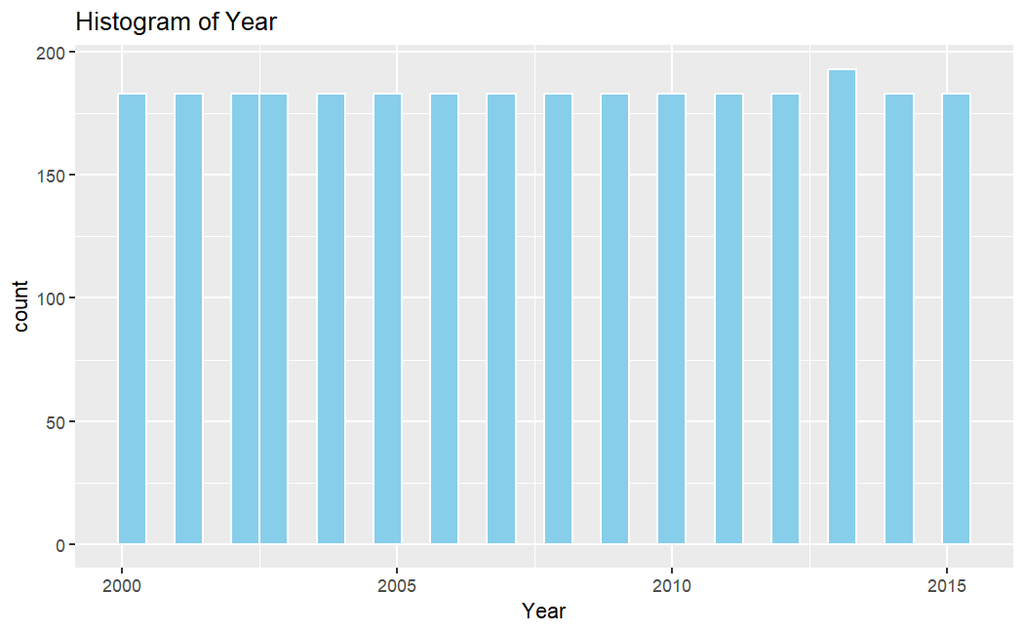

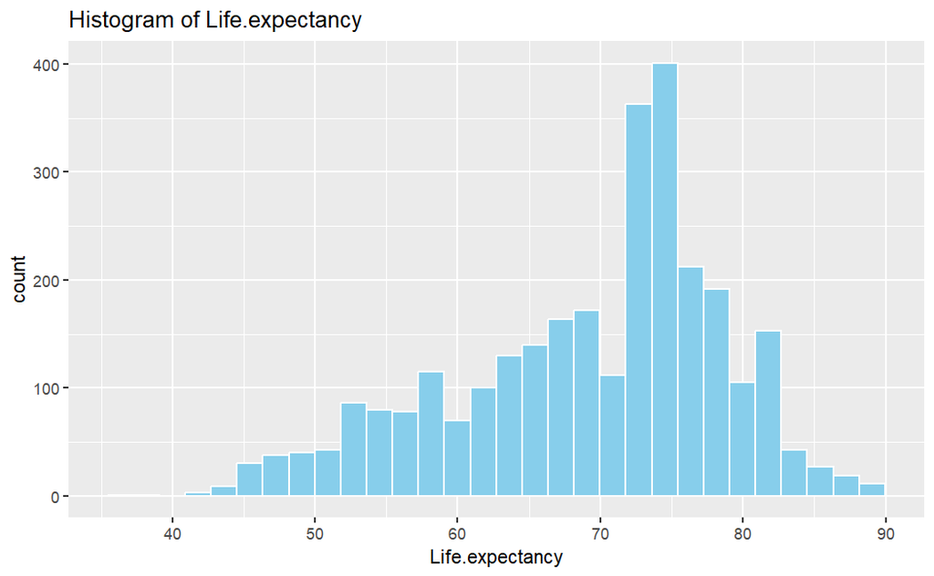

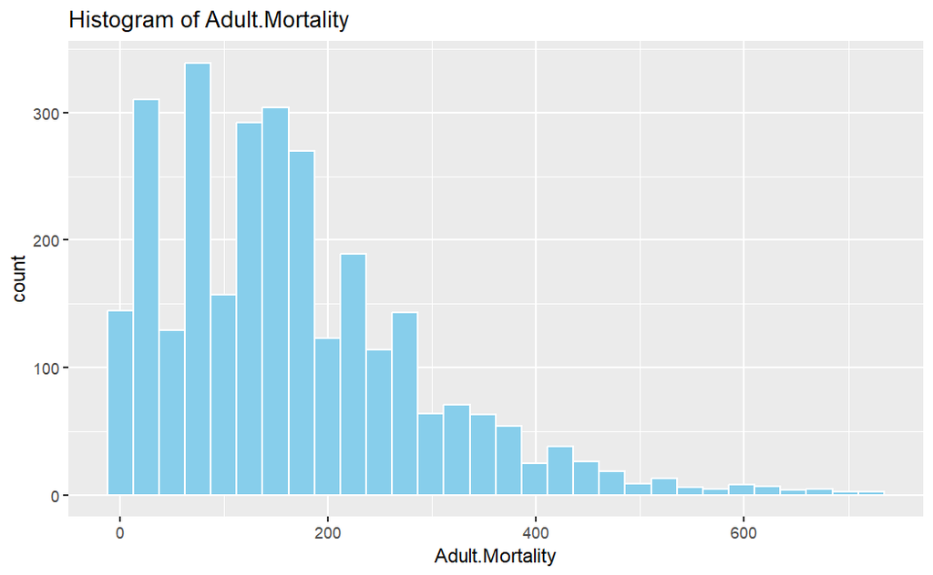

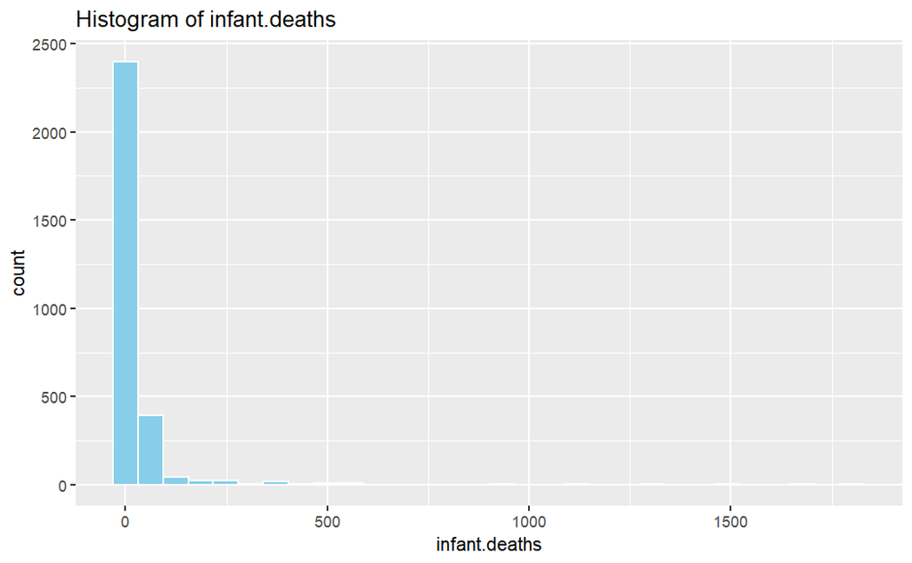

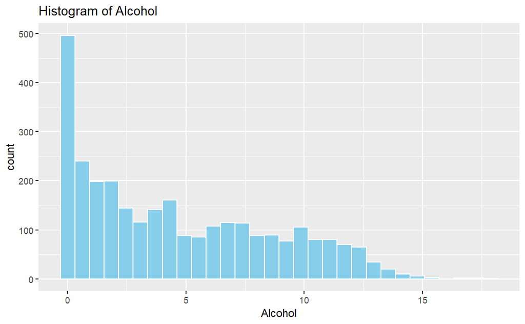

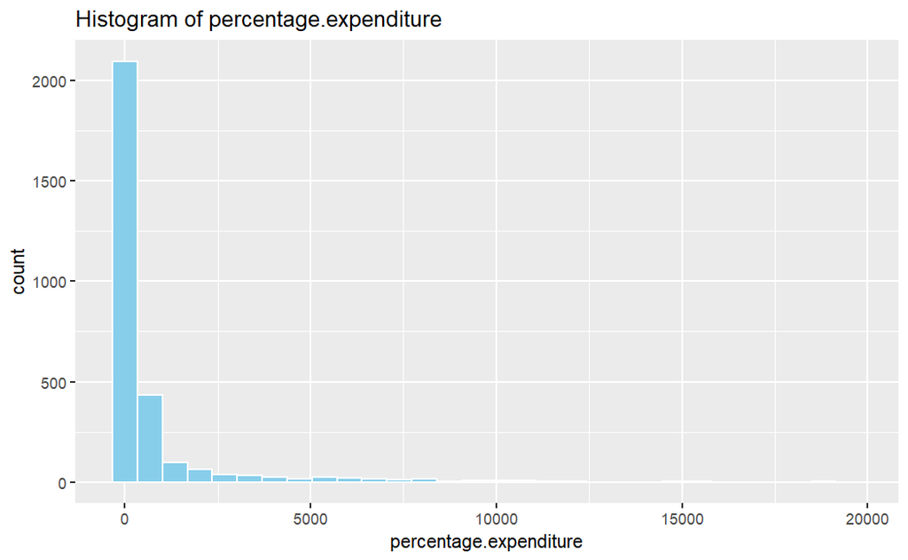

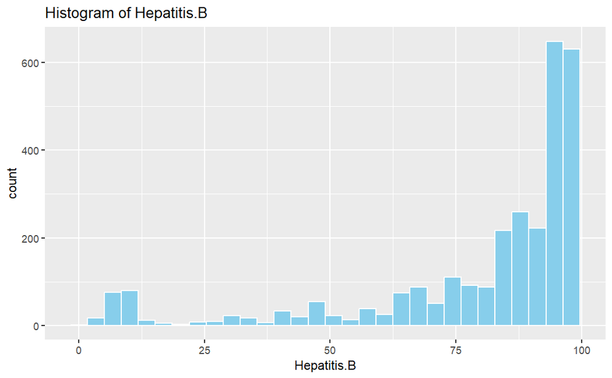

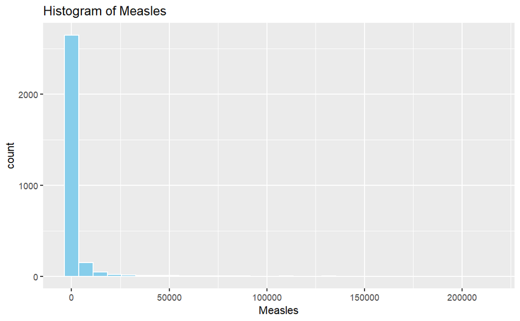

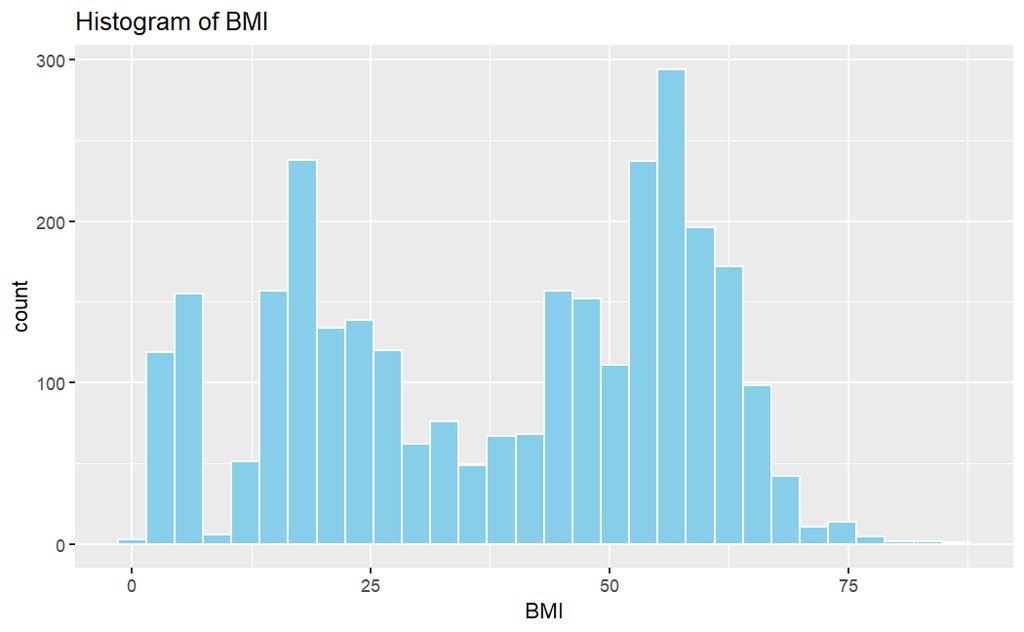

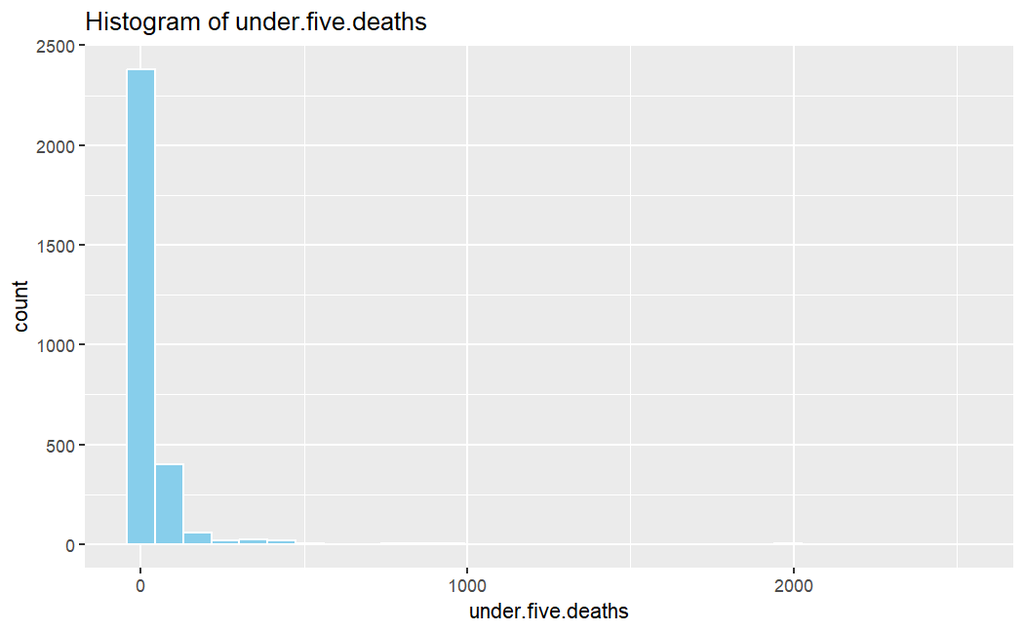

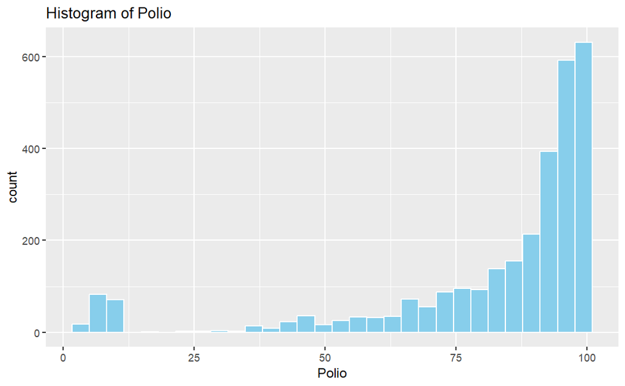

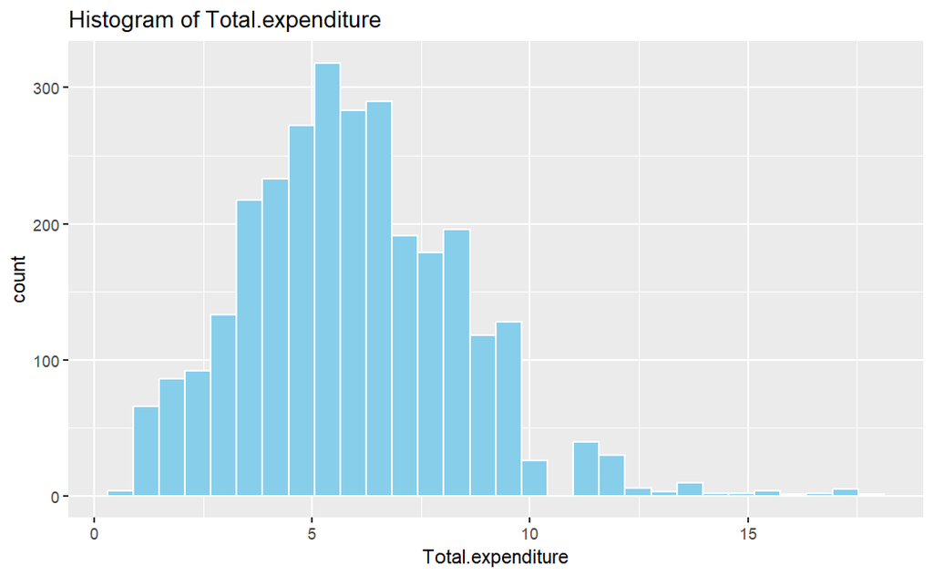

[8 more figures not shown]

```r
# Histograms for numerical columns
for (col in nums_col) {
  print(
    ggplot(WHO_life_expectancy_data, aes_string(x = col)) +
      geom_histogram(bins = 30, fill = "skyblue", color = "white") +
      ggtitle(paste("Histogram of", col))
  )
}
```

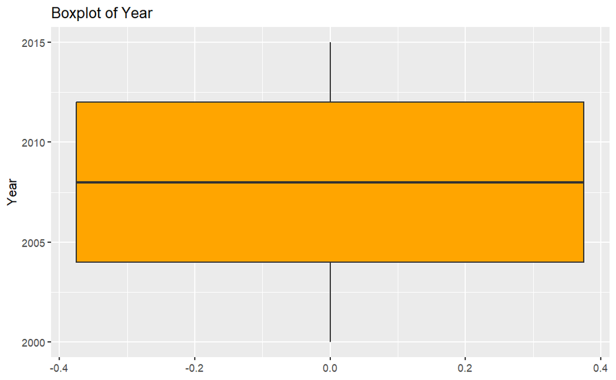

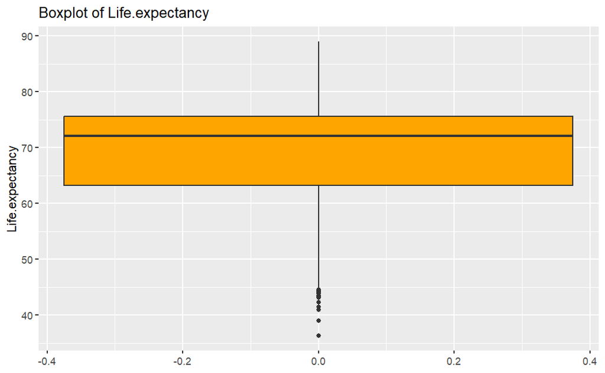

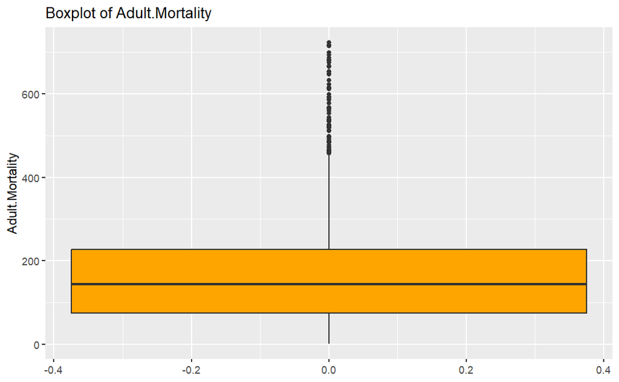

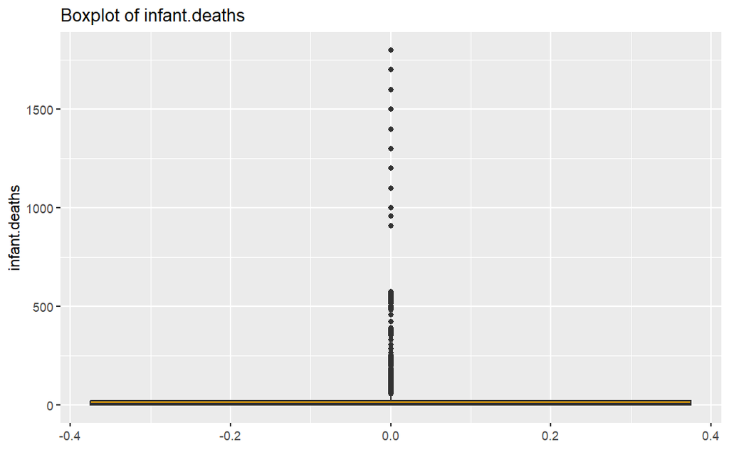

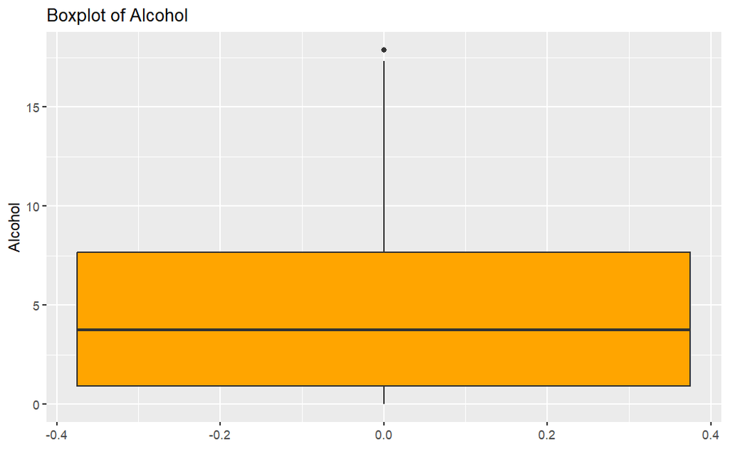

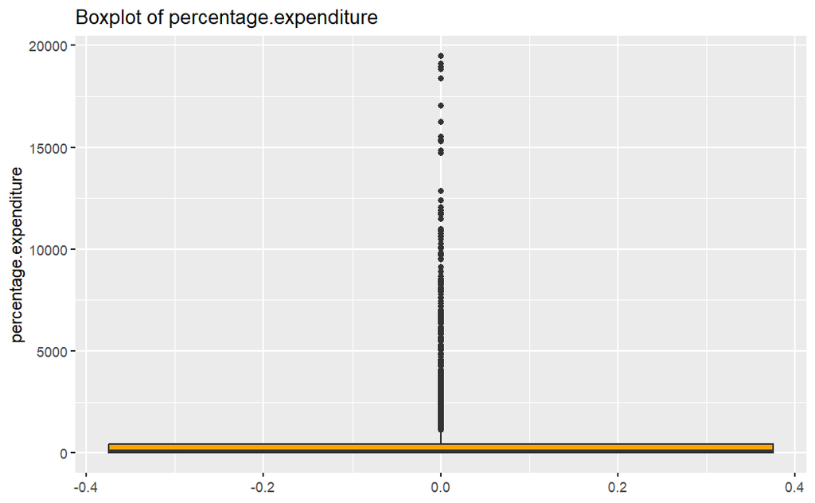

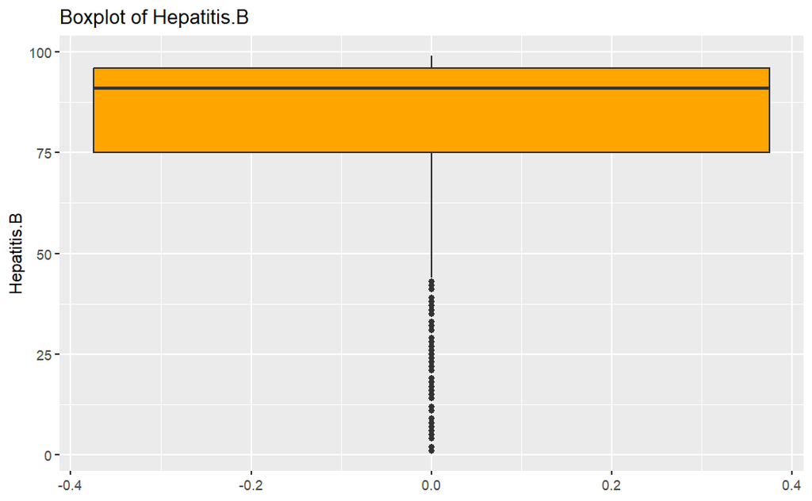

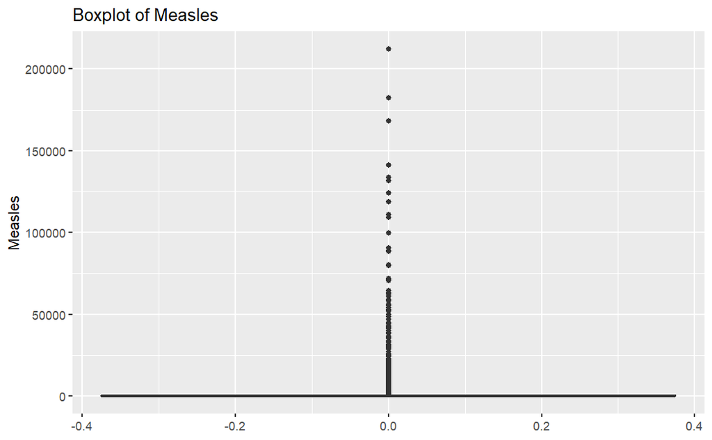

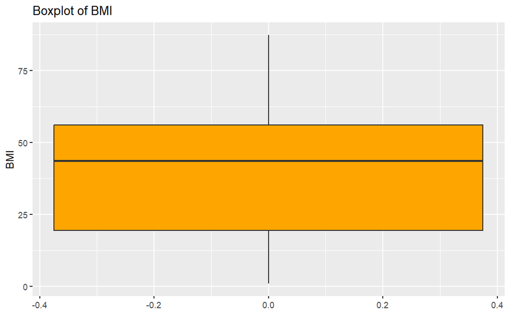

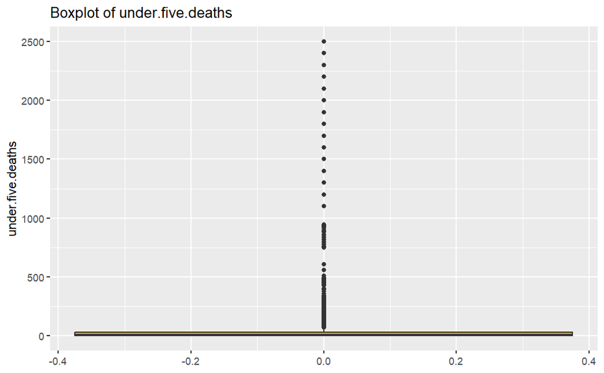

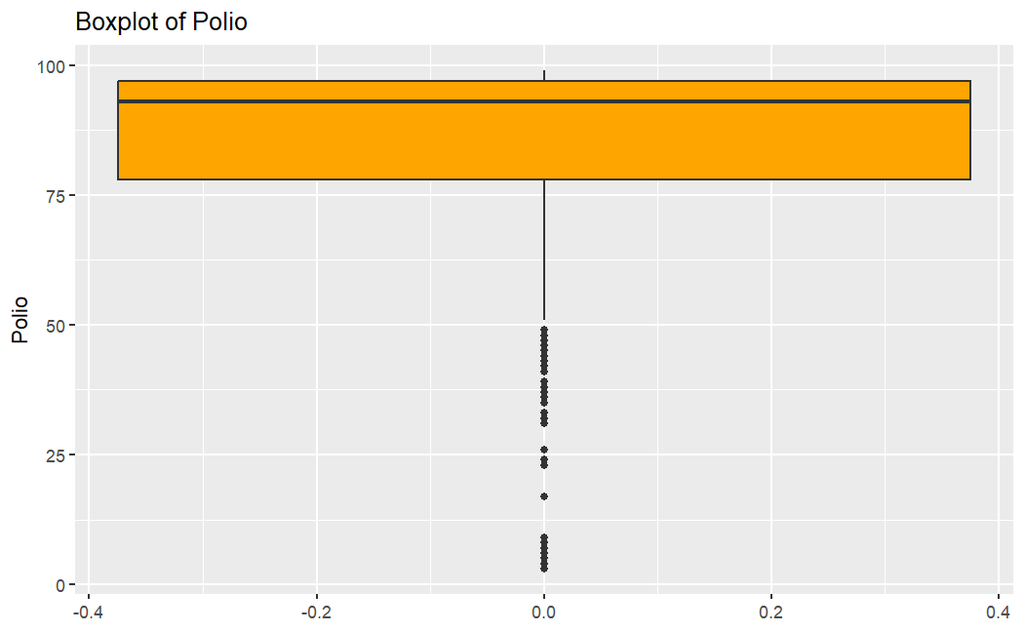

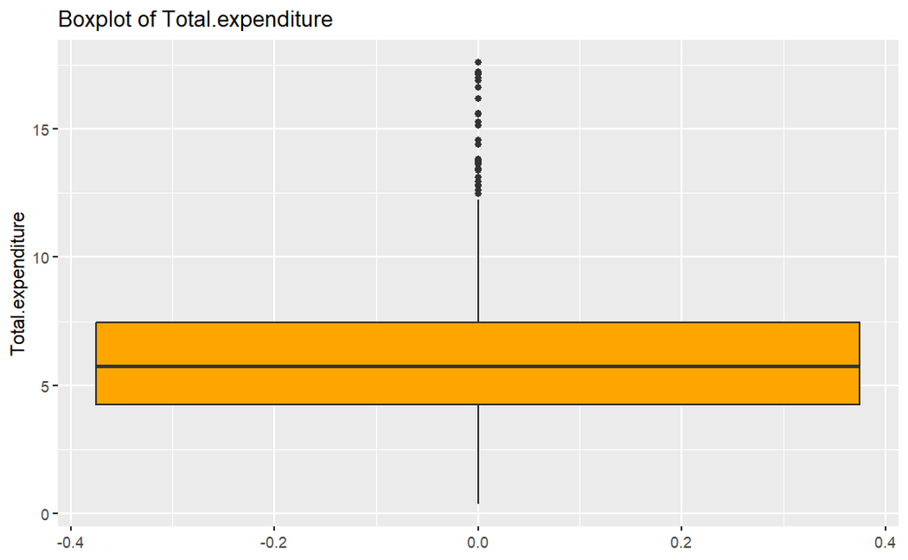

[8 more figures not shown]

```r
# Boxplots for numerical columns
for (col in nums_col) {
  print(
    ggplot(WHO_life_expectancy_data, aes_string(y = col)) +
      geom_boxplot(fill = "orange") +
      ggtitle(paste("Boxplot of", col))
  )
}
```

# **Step 6: Model Training**

We are now splitting the data into training and test sets becuase it prevents overfitting and provides unbiased evaluation.

```r
set.seed(123)
train_index <- createDataPartition(WHO_life_expectancy_data$Life.expectancy, p = 0.8, list = FALSE)
train_data <- WHO_life_expectancy_data[train_index, ]
test_data  <- WHO_life_expectancy_data[-train_index, ]
```

Now, we will be fitting the basic regression model with all predictors on the training set. This will establish a starting point, shows which variables matter and if data supports a linear relationship.

```r
model_baseline <- lm(Life.expectancy ~ ., data = train_data)
summary(model_baseline)
```

```
Call:
lm(formula = Life.expectancy ~ ., data = train_data)

Residuals:
    Min      1Q  Median      3Q     Max
-9.3037 -0.8847 -0.2165  0.4151  8.1724

Coefficients: (1 not defined because of singularities)
                                                              Estimate Std. Error
(Intercept)                                                 -4.664e+02  2.259e+01
CountryAlbania                                               1.640e+01  8.336e-01
CountryAlgeria                                               1.410e+01  7.743e-01
CountryAngola                                               -6.971e+00  7.808e-01
CountryAntigua and Barbuda                                   1.704e+01  8.386e-01
CountryArgentina                                             1.615e+01  8.945e-01
CountryArmenia                                               1.448e+01  8.258e-01
CountryAustralia                                             2.257e+01  9.942e-01
CountryAustria                                               2.294e+01  9.274e-01
CountryAzerbaijan                                            1.194e+01  7.943e-01
CountryBahamas                                               1.616e+01  8.596e-01
CountryBahrain                                               1.623e+01  8.626e-01
CountryBangladesh                                            9.945e+00  7.160e-01
CountryBarbados                                              1.558e+01  9.015e-01
CountryBelarus                                               1.185e+01  9.159e-01
CountryBelgium                                               2.136e+01  9.268e-01
CountryBelize                                                1.058e+01  8.359e-01
CountryBenin                                                -1.930e-01  7.528e-01
CountryBhutan                                                6.458e+00  7.535e-01
CountryBolivia (Plurinational State of)                      8.014e+00  8.843e-01
CountryBosnia and Herzegovina                                1.722e+01  8.075e-01
CountryBotswana                                              2.640e+00  8.688e-01
CountryBrazil                                                1.413e+01  8.400e-01
CountryBrunei Darussalam                                     1.682e+01  8.695e-01
CountryBulgaria                                              1.454e+01  8.790e-01
CountryBurkina Faso                                         -5.252e-01  7.654e-01
CountryBurundi                                              -1.300e+00  7.510e-01
CountryCabo Verde                                            1.342e+01  7.715e-01
CountryCambodia                                              5.636e+00  7.138e-01
CountryCameroon                                             -1.665e+00  7.579e-01
CountryCanada                                                2.193e+01  9.354e-01
```

[output cut: 362 more lines]

```
StatusDeveloping                                                 NA       NA
Adult.Mortality                                              -2.105 0.035404 *
infant.deaths                                                 5.162 2.66e-07 ***
Alcohol                                                      -3.139 0.001718 **
percentage.expenditure                                        2.151 0.031552 *
Hepatitis.B                                                  -1.201 0.229845
Measles                                                      -2.288 0.022251 *
BMI                                                          -1.572 0.116060
 [ reached getOption("max.print") -- omitted 11 rows ]
---
Signif. codes:  0 ‘***’ 0.001 ‘**’ 0.01 ‘*’ 0.05 ‘.’ 0.1 ‘ ’ 1

Residual standard error: 1.77 on 2141 degrees of freedom
Multiple R-squared:  0.9681,    Adjusted R-squared:  0.965
F-statistic: 310.7 on 209 and 2141 DF,  p-value: < 2.2e-16
```

Overall Interpretation The model fits the training data extremely well, with high R² and low residual error.

Country effects are the most important drivers, but other features (year, mortality, health expenditure, alcohol) are also influential.

Caution: With this many country dummies, the model may be overfitting or simply capturing country means. Stepwise selection or regularization is needed for model refinement.

```r
model_step <- stepAIC(model_baseline, direction = "both")
```

```
Start:  AIC=2883.89
Life.expectancy ~ Country + Year + Status + Adult.Mortality +
    infant.deaths + Alcohol + percentage.expenditure + Hepatitis.B +
    Measles + BMI + under.five.deaths + Polio + Total.expenditure +
    Diphtheria + HIV.AIDS + GDP + Population + thinness..1.19.years +
    thinness.5.9.years + Income.composition.of.resources + Schooling


Step:  AIC=2883.89
Life.expectancy ~ Country + Year + Adult.Mortality + infant.deaths +
    Alcohol + percentage.expenditure + Hepatitis.B + Measles +
    BMI + under.five.deaths + Polio + Total.expenditure + Diphtheria +
    HIV.AIDS + GDP + Population + thinness..1.19.years + thinness.5.9.years +
    Income.composition.of.resources + Schooling

                                   Df Sum of Sq   RSS    AIC
- thinness.5.9.years                1         0  6705 2882.0
- Income.composition.of.resources   1         1  6706 2882.1
- thinness..1.19.years              1         2  6707 2882.6
- Population                        1         4  6709 2883.1
- Hepatitis.B                       1         5  6710 2883.5
- GDP                               1         6  6711 2883.9
<none>                                           6705 2883.9
- Polio                             1         6  6712 2884.2
- BMI                               1         8  6713 2884.6
- Adult.Mortality                   1        14  6719 2886.7
- percentage.expenditure            1        14  6720 2887.0
- Total.expenditure                 1        15  6720 2887.0
- Measles                           1        16  6721 2887.6
- Alcohol                           1        31  6736 2892.7
- Diphtheria                        1        35  6740 2894.1
- Schooling                         1        45  6750 2897.6
- infant.deaths                     1        83  6788 2911.0
- under.five.deaths                 1        96  6801 2915.2
- HIV.AIDS                          1      1050  7755 3223.8
- Year                              1      1654  8359 3400.3
- Country                         190     31954 38659 6622.7

Step:  AIC=2882.02
Life.expectancy ~ Country + Year + Adult.Mortality + infant.deaths +
```

[output cut: 184 more lines]

```
+ thinness.5.9.years                1         3  6727 2879.6
- BMI                               1         8  6739 2879.7
+ Income.composition.of.resources   1         1  6730 2880.6
- percentage.expenditure            1        11  6742 2880.8
- Total.expenditure                 1        13  6744 2881.4
- Adult.Mortality                   1        14  6744 2881.6
- Measles                           1        18  6748 2882.9
- Alcohol                           1        31  6762 2887.7
- Schooling                         1        50  6781 2894.3
- Diphtheria                        1        53  6784 2895.4
- infant.deaths                     1        79  6809 2904.2
- under.five.deaths                 1        90  6821 2908.2
- HIV.AIDS                          1      1073  7804 3224.7
- Year                              1      1761  8491 3423.2
- Country                         190     33914 40644 6726.4
```

```r
summary(model_step)
```

```
Call:
lm(formula = Life.expectancy ~ Country + Year + Adult.Mortality +
    infant.deaths + Alcohol + percentage.expenditure + Measles +
    BMI + under.five.deaths + Total.expenditure + Diphtheria +
    HIV.AIDS + Schooling, data = train_data)

Residuals:
    Min      1Q  Median      3Q     Max
-9.4862 -0.8688 -0.2094  0.4074  8.2132

Coefficients:
                                                              Estimate Std. Error
(Intercept)                                                 -4.548e+02  2.142e+01
CountryAlbania                                               1.596e+01  7.433e-01
CountryAlgeria                                               1.381e+01  7.292e-01
CountryAngola                                               -7.361e+00  7.337e-01
CountryAntigua and Barbuda                                   1.667e+01  7.713e-01
CountryArgentina                                             1.570e+01  8.043e-01
CountryArmenia                                               1.405e+01  7.419e-01
CountryAustralia                                             2.199e+01  9.044e-01
CountryAustria                                               2.245e+01  8.449e-01
CountryAzerbaijan                                            1.157e+01  7.156e-01
CountryBahamas                                               1.577e+01  7.817e-01
CountryBahrain                                               1.586e+01  8.142e-01
CountryBangladesh                                            9.966e+00  7.095e-01
CountryBarbados                                              1.507e+01  8.402e-01
CountryBelarus                                               1.142e+01  8.406e-01
CountryBelgium                                               2.091e+01  8.324e-01
CountryBelize                                                1.021e+01  7.671e-01
CountryBenin                                                -3.860e-01  7.235e-01
CountryBhutan                                                6.652e+00  7.316e-01
CountryBolivia (Plurinational State of)                      7.556e+00  7.991e-01
CountryBosnia and Herzegovina                                1.686e+01  7.294e-01
CountryBotswana                                              2.392e+00  8.286e-01
CountryBrazil                                                1.365e+01  7.713e-01
CountryBrunei Darussalam                                     1.636e+01  8.129e-01
CountryBulgaria                                              1.408e+01  7.982e-01
CountryBurkina Faso                                         -8.036e-01  7.245e-01
CountryBurundi                                              -1.498e+00  7.174e-01
CountryCabo Verde                                            1.324e+01  7.391e-01
```

[output cut: 365 more lines]

```
Adult.Mortality                                              -2.100 0.035829 *
infant.deaths                                                 5.014 5.77e-07 ***
Alcohol                                                      -3.159 0.001607 **
percentage.expenditure                                        1.907 0.056632 .
Measles                                                      -2.367 0.018003 *
BMI                                                          -1.628 0.103755
under.five.deaths                                            -5.373 8.56e-08 ***
Total.expenditure                                            -2.042 0.041234 *
 [ reached getOption("max.print") -- omitted 3 rows ]
---
Signif. codes:  0 ‘***’ 0.001 ‘**’ 0.01 ‘*’ 0.05 ‘.’ 0.1 ‘ ’ 1

Residual standard error: 1.77 on 2148 degrees of freedom
Multiple R-squared:  0.968, Adjusted R-squared:  0.9649
F-statistic: 321.2 on 202 and 2148 DF,  p-value: < 2.2e-16
```